# Path Sampling: A Beginners Guide

[figure not shown]

# Open Path Sampling (OPS)

Open Path Sampling (OPS) is a python library to facilitate path sampling algorithms.

- Easy to use implementations of many variants of
  - Transition path sampling (TPS)
  - Transition interface sampling (TIS)
  - Committor analysis
  - Flux calculations.
- Independent of the underlying molecular dynamics engine
  - Currently supports OpenMM & internal engine suitable for 2D toy models

http://www.openpathsampling.org/

## Useful links:

- [OPS Installation] (http://openpathsampling.org/latest/install.html#install)
- [OPS API] (http://openpathsampling.org/latest/api_sections.html)
- [OPS Tutorials] (http://openpathsampling.org/latest/examples/index.html)
- [PLUMED Wrapper for OPS] (https://e-cam.readthedocs.io/en/latest/Classical-MD-Modules/modules/OpenPathSampling/ops_plumed_wrapper/readme.html)

[figure not shown]

PyRETIS is a Python library for rare event molecular simulations with emphasis on methods based on transition interface sampling and replica exchange transition interface sampling.

PyRETIS is open source, easy to use and can be interfaced with other simulation packages such as GROMACS, LAMMPS or CP2K.

http://www.pyretis.org/

# Let's Try This

# A Simple Toy Model

First we set up our system: for the toy dynamics, this involves defining a potential energy surface (PES), setting up an integrator, and giving the simulation an initial configuration.

## Import

```python
# Basic imports
%matplotlib inline
import numpy as np
import openpathsampling as paths

# convenience for the toy dynamics
import openpathsampling.engines.toy as toys

# used for visualization of the 2D toy system
# we use the %run magic because this isn't in a package
%run ./toy_plot_helpers.py
```

## Setup the system

First we need to describe the system we'll be simulating.

For the toy model, we need to give a snapshot as a template, as well as a potential energy surface.

[With biomolecular systems, this is often done with an initial PDB structure and a choice of force field.]

### PES & Topology

```python
# Toy_PES supports adding/subtracting various PESs.
# The OuterWalls PES type gives an x^6+y^6 boundary to the system.
pes = (toys.OuterWalls([2.0,2.0], [0.0,0.0])
       + toys.Gaussian(-0.7, [12.0, 0.5], [-0.5, 0.0])
       + toys.Gaussian(-0.7, [12.0, 0.5], [0.5, 0.0])
#      + toys.Gaussian(0.4, [25, 25], [0.0, 0.3])
      )
# Build topology
topology = toys.Topology(n_spatial=2, masses=[1.0, 1.0], pes=pes)
```

### Plot the PES

Now let's look at the potential energy surface we've created:

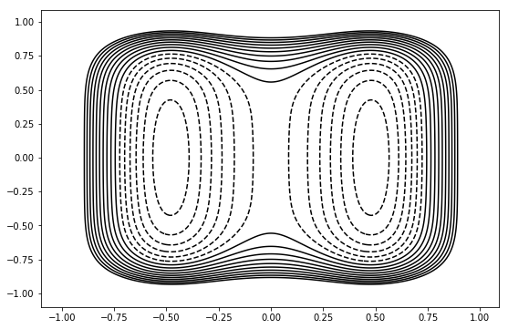

```python
plot = ToyPlot()
plot.contour_range = np.arange(-1.5, 1.0, 0.1)
plot.add_pes(pes)
fig = plot.plot()
```

### Set up the engine & snapshot

The engine needs the template snapshot we set up above, as well as an integrator and a few other options.

```python
# we will use the toy-engine coming with OpenMM
engine = toys.Engine(options={'integ': toys.LangevinBAOABIntegrator(dt=0.02, temperature=0.1, gamma=2.5),
                              'n_frames_max': 5000,
                              'n_steps_per_frame': 10},
                              topology=topology)
```

```python
template = toys.Snapshot(coordinates=np.array([[0.0, 0.0]]),
                         velocities=np.array([[0.0, 0.0]]),
                         engine=engine)
```

## Define States

TPS methods require that you define your states before starting the simulation.

```python
# states are volumes in a CV space: define the CV
def xval(snapshot):
    return snapshot.xyz[0][0]

cv = paths.FunctionCV("xval", xval)
```

Only take the **x** coordinate

We define stateA as anything lower than x=-0.5, stateB anything higher than x=0.5

```python
stateA = paths.CVDefinedVolume(cv, float("-inf"), -0.5).named("A")
stateB = paths.CVDefinedVolume(cv, 0.5, float("inf")).named("B")
```

### Plot states

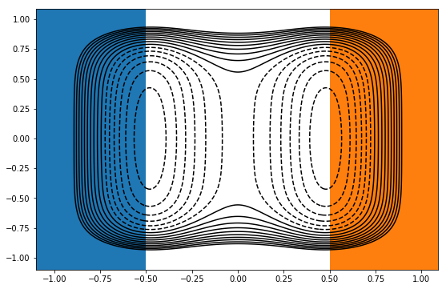

```python
plot = ToyPlot()
plot.contour_range = np.arange(-1.5, 1.0, 0.1) # Determines the number and positions of the contour lines / regions
plot.add_pes(pes)
fig = plot.plot()
ax = fig.gca() # Get the current Axes
ax.set_ylim(ax.get_ylim())
ax.fill_betweenx(np.linspace(-1.5,1.5),ax.get_xlim()[0],stateA.lambda_max) # "Left" State
ax.fill_betweenx(np.linspace(-1.5,1.5),stateB.lambda_min,ax.get_xlim()[1]) # "Right" State
```

## Prepare path sampling

### Set up the network and move scheme

This is a simple path sampling setup. We use the same TPSNetwork we'll use later for "real" systems, and only one way shooting moves.

```python
# This is important!
# Here you decide on which kind of path sampling you are going to do
network = paths.TPSNetwork(stateA, stateB)
# Here you decide on which kind of shooting move you are going to use
scheme = paths.OneWayShootingMoveScheme(network, engine=engine)
```

### Getting a first trajectory

Path sampling methods require that the user supply an input path for each path ensemble. This means that you must somehow generate a first input path.

This can be quite challenging and not trivial.

Here, however, we will just fake an initial trajectory.

```python
trajectory = paths.Trajectory([
    toys.Snapshot(coordinates=np.array([[-.55+k*0.1, 0.0]]), # You might want to change these
                  velocities=np.array([[0.1, 0.0]]),
                  engine=engine)
    for k in range(12)
])
```

### Prepare initial conditions

Create a SampleSet with as many initial samples as possible, make subtrajectories into initial conditions (trajectories become a sampleset)

```python
initial_conditions = scheme.initial_conditions_from_trajectories(trajectory)
```

```
No missing ensembles.
No extra ensembles.
```

### Now let's have a look at our system

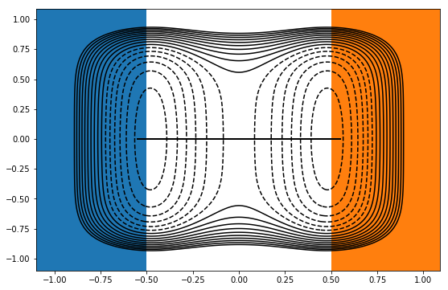

```python
plot = ToyPlot()
plot.contour_range = np.arange(-1.5, 1.0, 0.1)
plot.add_pes(pes)
fig = plot.plot(bold=[trajectory])
ax = fig.gca()
ax.set_ylim(ax.get_ylim())
ax.fill_betweenx(np.linspace(-1.5,1.5),ax.get_xlim()[0],stateA.lambda_max)
ax.fill_betweenx(np.linspace(-1.5,1.5),stateB.lambda_min,ax.get_xlim()[1])
```

## Run path sampling

```python
%pwd
```

```
'/home/jabobs/teaching/workshop_OpenMM/OPS_introduction'
```

### Create storage and simulation object

Up to this point, we haven't stored anything in files.

The storage itself is mainly a netCDF file and can also be used as such. (netCDF files are very generic while the OPS Storage is more tuned to needs we have. It supports etc native support for simtk.units)

```python
%rm -f ./resource/toymodel.nc
storage = paths.Storage("./resource/toymodel.nc", "w", template=template)
```

Create the PathSampling object

```python
simulation = paths.PathSampling(storage, scheme, initial_conditions)
```

### Run the simulation

We could simply start the simulation with simulation.run - but wouldn't it be great to see what we are doing?

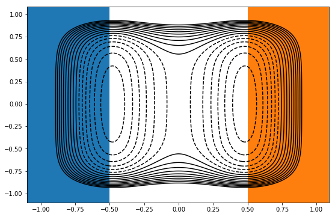

```python
xval = paths.FunctionCV("xval", lambda snap : snap.xyz[0][0])
yval = paths.FunctionCV("yval", lambda snap : snap.xyz[0][1])
# Visualize the last step of a path sampling simulation using StepVisualizer2D:
simulation.live_visualizer = paths.StepVisualizer2D(network, xval, yval, [-1.0, 1.0], [-1.0, 1.0])
background = ToyPlot()
background.contour_range = np.arange(-1.5, 1.0, 0.1)
background.add_pes(engine.pes)
fig = background.plot()
ax = fig.gca()
ax.set_ylim(ax.get_ylim())
ax.fill_betweenx(np.linspace(-1.5,1.5),ax.get_xlim()[0],stateA.lambda_max)
ax.fill_betweenx(np.linspace(-1.5,1.5),stateB.lambda_min,ax.get_xlim()[1])
simulation.live_visualizer.background = fig
simulation.status_update_frequency = 1 # increasing this number speeds things up, but isn't as pretty
```

Run our toy system for 100 steps.

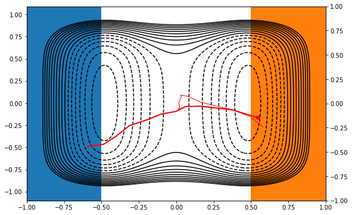

```
DONE! Completed 100 Monte Carlo cycles.
```

```python
simulation.run_until(100)
```

```python
# storage.sync()  # sync
# storage.close() # close the file
```

# Analysis

Let's have a look at the path ensemble we generated

```python
# import openpathsampling as paths
# filename = "./resource/toymodel.nc"
# storage = paths.AnalysisStorage(filename, caching_mode='analysis')
```

How much data have we generated?

```python
print("File size: {0} for {1} steps, {2} snapshots".format(
    storage.file_size_str,
    len(storage.steps),
    len(storage.snapshots)
))
```

```
File size: 99.13MB for 101 steps, 1252 snapshots
```

Okay, now let's start to analyze the contents of our file.

We used a very simple move scheme (only shooting), so the main information that the move_summary gives us is the acceptance of the only kind of move in that scheme.

```python
engine = storage.engines[0]
flex_scheme = storage.schemes[0]
flex_scheme.move_summary(storage.steps) # anything above 30% is considered good, above 50% very good
```

```
shooting ran 100.000% (expected 100.00%) of the cycles with acceptance 49/100 (49.00%)
```

## Replica history tree and decorrelated trajectories

The ReplicaHistoryTree object gives us both the history tree (often called the "move tree") and the number of decorrelated trajectories.

```python
import openpathsampling.visualize as ops_vis
from IPython.display import SVG
from IPython import display

replica_history = ops_vis.ReplicaEvolution(replica=0)
tree = ops_vis.PathTree(
    storage.steps[0:30],
    replica_history
)
tree.options.css['scale_x'] = 10
```

```python
# can write to svg file and open with programs that can read SVG
%rm -f ./resource/flex_tps_tree_1.svg
with open("./resource/flex_tps_tree_1.svg", 'w') as f:
    f.write(tree.svg())
```

[figure not shown]

We can make things a bit prettier

```python
tree.options.movers['default']['new'] = 'single'
tree.options.css['scale_x'] = 10
tree.options.css['horizontal_gap'] = 0.1  # True is the same as 0.05

# can write to svg file and open with programs that can read SVG
%rm -f ./resource/flex_tps_tree_2.svg
with open("./resource/flex_tps_tree_2.svg", 'w') as f:
    f.write(tree.svg())
```

[figure not shown]

As we have seen before, decorrelation of our sampled trajectories can be a problem.

The ReplicaHistoryTree allows us to check this:

```python
print("Decorrelated trajectories:", len(tree.generator.decorrelated_trajectories))
print("Indices:", tree.generator.decorrelated_trajectories)
```

```
Decorrelated trajectories: 1
Indices: [Trajectory[12]]
```

## Path length distribution

Flexible length TPS gives a distribution of path lengths.

Here we calculate the length of every accepted trajectory, then histogram those lengths, and calculate the maximum and average path lengths.

```
Maximum: 30
Average: 16.67
```

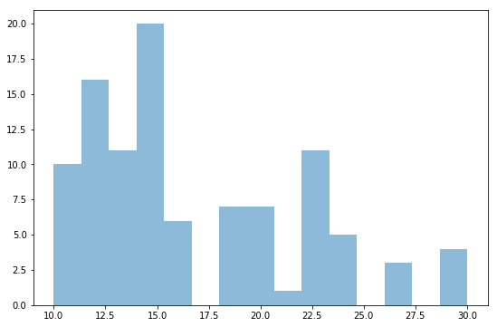

```python
path_lengths = [len(step.active[0].trajectory) for step in storage.steps]
plt.hist(path_lengths, bins=15, alpha=0.5);
print("Maximum:", max(path_lengths))
print("Average:", "{0:.2f}".format(np.mean(path_lengths)))
```

## Path ensemble

We can visualize all accepted trajectories:

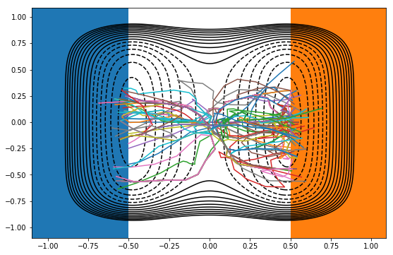

```python
fig = background.plot()
ax = fig.gca()
ax.set_ylim(ax.get_ylim())
ax.fill_betweenx(np.linspace(-1.5,1.5),ax.get_xlim()[0],stateA.lambda_max)
ax.fill_betweenx(np.linspace(-1.5,1.5),stateB.lambda_min,ax.get_xlim()[1])
for traj in storage.trajectories:
    ax.plot(traj.xyz[:,0,0], traj.xyz[:,0,1])
```

# Outlook: A "Real" System

Here are the most important steps for running a TPS simulation on alanine dipetide.

We use dihedrals as cvs, and a previously generated trajectory as initial trajectory.

```python
%matplotlib inline
import matplotlib.pyplot as plt
import openpathsampling as paths

import openpathsampling.engines.openmm as omm
from simtk.openmm import app
import simtk.openmm as mm
import simtk.unit as unit
from openmmtools.integrators import VVVRIntegrator
import mdtraj as md
import numpy as np
```

## Set up the engine

First, we set things up for the OpenMM simulation. We will need a openmm.System object and an openmm.Integrator object.

```python
# this cell is all OpenMM specific
forcefield = app.ForceField('amber96.xml', 'tip3p.xml') # our forcefield & water model
pdb = app.PDBFile("./AD_initial_frame.pdb")   # pdb file of alanine dipeptide
system = forcefield.createSystem(
    pdb.topology,
    nonbondedMethod=app.PME,
    nonbondedCutoff=1.0*unit.nanometers,
    constraints=app.HBonds,
    rigidWater=True,
    ewaldErrorTolerance=0.0005
)
integrator = VVVRIntegrator( # Velocity Verlet with velocity randomization (VVVR) integrator.
    300*unit.kelvin,
    1.0/unit.picoseconds,
    2.0*unit.femtoseconds
)
integrator.setConstraintTolerance(0.00001)

engine = omm.Engine(
    template.topology,
    system,
    integrator,
    openmm_properties=openmm_properties,
    options=engine_options
)

engine.name = '300K'
```

[output not shown]

The storage file will need a template snapshot.

In addition, the OPS OpenMM-based Engine has a few properties and options that are set by these dictionaries.

```python
template = omm.snapshot_from_pdb("./AD_initial_frame.pdb")
openmm_properties = {'OpenCLPrecision': 'mixed'}
engine_options = {
    'n_steps_per_frame': 10,
    'n_frames_max': 2000
}
```

We load a trajectory we generated previously at high temperature, connecting our two states.

```python
# without velocities
from openpathsampling.engines.openmm.tools import ops_load_trajectory

traj = ops_load_trajectory("trajectory_file.xtc", top="conf.gro")
```

```python
# with velocities we can use MDAnalysis
import mdtraj as md
from openpathsampling.engines.openmm.tools import trajectory_from_mdtraj

mdt = md.load("trajectory_file.trr", top="conf.gro")
# next two lines create numpy array for velocities
trr = md.formats.TRRTrajectoryFile("trajectory_file.trr")
vel = trr._read(n_frames=len(mdt), atom_indices=None, get_velocities=True)[5]
# combine `mdt` and `vel` in an OPS trajectory
traj = trajectory_from_mdtraj(mdt, velocities=vel)
```

## Define The States

First we define the CVs using the md.compute_dihedrals function. Then we define our states using PeriodicCVDefinedVolume (since our CVs are periodic.)

```python
# define the CVs
psi = paths.MDTrajFunctionCV("psi", md.compute_dihedrals, template.topology, indices=[[6,8,14,16]])
phi = paths.MDTrajFunctionCV("phi", md.compute_dihedrals, template.topology, indices=[[4,6,8,14]])
```

```python
# define the states
deg = 180.0/np.pi
C_7eq = (
    paths.PeriodicCVDefinedVolume(phi, lambda_min=-180/deg, lambda_max=0/deg,
                                  period_min=-np.pi, period_max=np.pi) &
    paths.PeriodicCVDefinedVolume(psi, lambda_min=100/deg, lambda_max=200/deg,
                                  period_min=-np.pi, period_max=np.pi)
).named("C_7eq")
# similarly, without bothering with the labels:
alpha_R = (paths.PeriodicCVDefinedVolume(phi, -180/deg, 0/deg, -np.pi, np.pi) &
           paths.PeriodicCVDefinedVolume(psi, -100/deg, 0/deg, -np.pi, np.pi)).named("alpha_R")
```

## Run the TPS

As always, the process for setting up a simulation is:

```
Create a network
Create a move scheme
Set up initial_conditions
Create the PathSampling object and run it.
```

```python
network = paths.TPSNetwork(C_7eq, alpha_R)

scheme = paths.OneWayShootingMoveScheme(network, selector=paths.UniformSelector(), engine=engine)

initial_conditions = scheme.initial_conditions_from_trajectories(traj)
```

```python
storage_tps = paths.Storage("./resource/alanine_dipeptide_tps.nc", "w", template)
sampler_tps = paths.PathSampling(storage=storage_tps,
                             move_scheme=scheme,
                             sample_set=initial_conditions).named("Flexible_TPS_Sampling")
```

```python
#sampler.live_visualizer = paths.StepVisualization2D(network, phi, psi, [-3.14, 3.14], [-3.14, 3.14])
sampler_tps.run(10000)
```

# Now You Should be Ready to Run Your Own TPS Simulation :)

[figure not shown]

```python
print("Thank You!")
```